# Optimal Treatment Analysis

## Outcome Variable

**Outcome Variable:** ever_wasted

## Predictor Variables

**Intervention Variable:** single

**Adjustment Set:**

- arm
- W_mage
- meducyrs
- feducyrs
- W_mhtcm
- W_mwtkg
- W_mbmi
- delta_W_mage
- delta_meducyrs
- delta_feducyrs
- delta_W_mhtcm
- delta_W_mwtkg
- delta_W_mbmi

## Stratifying Variables

The analysis was stratified on these variable(s):

- agecat
- studyid
- country

## Data Summary

| agecat | studyid | country | single | ever_wasted | n_cell | n |
| --- | --- | --- | --- | --- | --- | --- |
| 0-24 months | ki0047075b-MAL-ED | BANGLADESH | 0 | 0 | 176 | 263 |
| 0-24 months | ki0047075b-MAL-ED | BANGLADESH | 0 | 1 | 87 | 263 |
| 0-24 months | ki0047075b-MAL-ED | BANGLADESH | 1 | 0 | 0 | 263 |
| 0-24 months | ki0047075b-MAL-ED | BANGLADESH | 1 | 1 | 0 | 263 |
| 0-24 months | ki0047075b-MAL-ED | BRAZIL | 0 | 0 | 182 | 233 |
| 0-24 months | ki0047075b-MAL-ED | BRAZIL | 0 | 1 | 15 | 233 |
| 0-24 months | ki0047075b-MAL-ED | BRAZIL | 1 | 0 | 32 | 233 |
| 0-24 months | ki0047075b-MAL-ED | BRAZIL | 1 | 1 | 4 | 233 |
| 0-24 months | ki0047075b-MAL-ED | INDIA | 0 | 0 | 132 | 249 |
| 0-24 months | ki0047075b-MAL-ED | INDIA | 0 | 1 | 117 | 249 |
| 0-24 months | ki0047075b-MAL-ED | INDIA | 1 | 0 | 0 | 249 |
| 0-24 months | ki0047075b-MAL-ED | INDIA | 1 | 1 | 0 | 249 |
| 0-24 months | ki0047075b-MAL-ED | NEPAL | 0 | 0 | 171 | 240 |
| 0-24 months | ki0047075b-MAL-ED | NEPAL | 0 | 1 | 69 | 240 |
| 0-24 months | ki0047075b-MAL-ED | NEPAL | 1 | 0 | 0 | 240 |
| 0-24 months | ki0047075b-MAL-ED | NEPAL | 1 | 1 | 0 | 240 |
| 0-24 months | ki0047075b-MAL-ED | PERU | 0 | 0 | 248 | 302 |
| 0-24 months | ki0047075b-MAL-ED | PERU | 0 | 1 | 20 | 302 |
| 0-24 months | ki0047075b-MAL-ED | PERU | 1 | 0 | 28 | 302 |
| 0-24 months | ki0047075b-MAL-ED | PERU | 1 | 1 | 6 | 302 |
| 0-24 months | ki0047075b-MAL-ED | SOUTH AFRICA | 0 | 0 | 143 | 312 |
| 0-24 months | ki0047075b-MAL-ED | SOUTH AFRICA | 0 | 1 | 33 | 312 |
| 0-24 months | ki0047075b-MAL-ED | SOUTH AFRICA | 1 | 0 | 108 | 312 |
| 0-24 months | ki0047075b-MAL-ED | SOUTH AFRICA | 1 | 1 | 28 | 312 |
| 0-24 months | ki0047075b-MAL-ED | TANZANIA, UNITED REPUBLIC OF | 0 | 0 | 222 | 261 |
| 0-24 months | ki0047075b-MAL-ED | TANZANIA, UNITED REPUBLIC OF | 0 | 1 | 29 | 261 |
| 0-24 months | ki0047075b-MAL-ED | TANZANIA, UNITED REPUBLIC OF | 1 | 0 | 7 | 261 |
| 0-24 months | ki0047075b-MAL-ED | TANZANIA, UNITED REPUBLIC OF | 1 | 1 | 3 | 261 |
| 0-24 months | ki1066203-TanzaniaChild2 | TANZANIA, UNITED REPUBLIC OF | 0 | 0 | 1643 | 2375 |
| 0-24 months | ki1066203-TanzaniaChild2 | TANZANIA, UNITED REPUBLIC OF | 0 | 1 | 508 | 2375 |

[output cut: 138 more lines]

The following strata were considered:

- agecat: 0-24 months, studyid: ki0047075b-MAL-ED, country: BANGLADESH
- agecat: 0-24 months, studyid: ki0047075b-MAL-ED, country: BRAZIL
- agecat: 0-24 months, studyid: ki0047075b-MAL-ED, country: INDIA
- agecat: 0-24 months, studyid: ki0047075b-MAL-ED, country: NEPAL
- agecat: 0-24 months, studyid: ki0047075b-MAL-ED, country: PERU
- agecat: 0-24 months, studyid: ki0047075b-MAL-ED, country: SOUTH AFRICA
- agecat: 0-24 months, studyid: ki0047075b-MAL-ED, country: TANZANIA, UNITED REPUBLIC OF
- agecat: 0-24 months, studyid: ki1066203-TanzaniaChild2, country: TANZANIA, UNITED REPUBLIC OF
- agecat: 0-24 months, studyid: ki1112895-Guatemala BSC, country: GUATEMALA
- agecat: 0-24 months, studyid: ki1119695-PROBIT, country: BELARUS
- agecat: 0-24 months, studyid: ki1126311-ZVITAMBO, country: ZIMBABWE
- agecat: 0-24 months, studyid: ki1135781-COHORTS, country: GUATEMALA
- agecat: 0-24 months, studyid: ki1135781-COHORTS, country: INDIA
- agecat: 0-24 months, studyid: ki1135781-COHORTS, country: PHILIPPINES
- agecat: 0-6 months, studyid: ki0047075b-MAL-ED, country: BANGLADESH
- agecat: 0-6 months, studyid: ki0047075b-MAL-ED, country: BRAZIL
- agecat: 0-6 months, studyid: ki0047075b-MAL-ED, country: INDIA
- agecat: 0-6 months, studyid: ki0047075b-MAL-ED, country: NEPAL
- agecat: 0-6 months, studyid: ki0047075b-MAL-ED, country: PERU
- agecat: 0-6 months, studyid: ki0047075b-MAL-ED, country: SOUTH AFRICA
- agecat: 0-6 months, studyid: ki0047075b-MAL-ED, country: TANZANIA, UNITED REPUBLIC OF
- agecat: 0-6 months, studyid: ki1066203-TanzaniaChild2, country: TANZANIA, UNITED REPUBLIC OF
- agecat: 0-6 months, studyid: ki1112895-Guatemala BSC, country: GUATEMALA
- agecat: 0-6 months, studyid: ki1119695-PROBIT, country: BELARUS
- agecat: 0-6 months, studyid: ki1126311-ZVITAMBO, country: ZIMBABWE
- agecat: 0-6 months, studyid: ki1135781-COHORTS, country: GUATEMALA
- agecat: 0-6 months, studyid: ki1135781-COHORTS, country: INDIA
- agecat: 0-6 months, studyid: ki1135781-COHORTS, country: PHILIPPINES
- agecat: 6-24 months, studyid: ki0047075b-MAL-ED, country: BANGLADESH
- agecat: 6-24 months, studyid: ki0047075b-MAL-ED, country: BRAZIL
- agecat: 6-24 months, studyid: ki0047075b-MAL-ED, country: INDIA
- agecat: 6-24 months, studyid: ki0047075b-MAL-ED, country: NEPAL
- agecat: 6-24 months, studyid: ki0047075b-MAL-ED, country: PERU
- agecat: 6-24 months, studyid: ki0047075b-MAL-ED, country: SOUTH AFRICA
- agecat: 6-24 months, studyid: ki0047075b-MAL-ED, country: TANZANIA, UNITED REPUBLIC OF
- agecat: 6-24 months, studyid: ki1066203-TanzaniaChild2, country: TANZANIA, UNITED REPUBLIC OF
- agecat: 6-24 months, studyid: ki1112895-Guatemala BSC, country: GUATEMALA
- agecat: 6-24 months, studyid: ki1119695-PROBIT, country: BELARUS
- agecat: 6-24 months, studyid: ki1126311-ZVITAMBO, country: ZIMBABWE
- agecat: 6-24 months, studyid: ki1135781-COHORTS, country: GUATEMALA
- agecat: 6-24 months, studyid: ki1135781-COHORTS, country: INDIA
- agecat: 6-24 months, studyid: ki1135781-COHORTS, country: PHILIPPINES

### Dropped Strata

Some strata were dropped due to rare outcomes:

- agecat: 0-24 months, studyid: ki0047075b-MAL-ED, country: BANGLADESH
- agecat: 0-24 months, studyid: ki0047075b-MAL-ED, country: BRAZIL
- agecat: 0-24 months, studyid: ki0047075b-MAL-ED, country: INDIA
- agecat: 0-24 months, studyid: ki0047075b-MAL-ED, country: NEPAL
- agecat: 0-24 months, studyid: ki0047075b-MAL-ED, country: TANZANIA, UNITED REPUBLIC OF
- agecat: 0-24 months, studyid: ki1112895-Guatemala BSC, country: GUATEMALA
- agecat: 0-24 months, studyid: ki1135781-COHORTS, country: INDIA
- agecat: 0-6 months, studyid: ki0047075b-MAL-ED, country: BANGLADESH
- agecat: 0-6 months, studyid: ki0047075b-MAL-ED, country: BRAZIL
- agecat: 0-6 months, studyid: ki0047075b-MAL-ED, country: INDIA
- agecat: 0-6 months, studyid: ki0047075b-MAL-ED, country: NEPAL
- agecat: 0-6 months, studyid: ki0047075b-MAL-ED, country: PERU
- agecat: 0-6 months, studyid: ki0047075b-MAL-ED, country: TANZANIA, UNITED REPUBLIC OF
- agecat: 0-6 months, studyid: ki1112895-Guatemala BSC, country: GUATEMALA
- agecat: 0-6 months, studyid: ki1135781-COHORTS, country: GUATEMALA
- agecat: 0-6 months, studyid: ki1135781-COHORTS, country: INDIA
- agecat: 6-24 months, studyid: ki0047075b-MAL-ED, country: BANGLADESH
- agecat: 6-24 months, studyid: ki0047075b-MAL-ED, country: BRAZIL
- agecat: 6-24 months, studyid: ki0047075b-MAL-ED, country: INDIA
- agecat: 6-24 months, studyid: ki0047075b-MAL-ED, country: NEPAL
- agecat: 6-24 months, studyid: ki0047075b-MAL-ED, country: PERU
- agecat: 6-24 months, studyid: ki0047075b-MAL-ED, country: TANZANIA, UNITED REPUBLIC OF
- agecat: 6-24 months, studyid: ki1112895-Guatemala BSC, country: GUATEMALA
- agecat: 6-24 months, studyid: ki1119695-PROBIT, country: BELARUS
- agecat: 6-24 months, studyid: ki1135781-COHORTS, country: INDIA

## Methods Detail

We’re interested in the causal parameters $E[Y_a]$ for all values of $a \in \mathcal{A}$. These parameters represent the mean outcome if, possibly contrary to fact, we intervened to set all units to have $A=a$. Under the randomization and positivity assumptions, these are identified by the statistical parameters $\psi_a=E_W[E_{Y|A,W}(Y|A=a,W)]$. In addition, we’re interested in the mean of $Y$, $E[Y]$ under no intervention (the observed mean). We will estimate these parameters by using SuperLearner to fit the relevant likelihood factors – $E_{Y|A,W}(Y|A=a,W)$ and $p(A=a|W)$, and then updating our likelihood fit using a joint TMLE.

For unadjusted analyses ($W=\{\}$), initial likelihoods were estimated using Lrnr_glm to estimate the simple $E(Y|A)$ and Lrnr_mean to estimate $p(A)$. For adjusted analyses, a small library containing Lrnr_glmnet, Lrnr_xgboost, and Lrnr_mean was used.

Having estimated these parameters, we will then use the delta method to estimate relative risks and attributable risks relative to a prespecified baseline level of $A$.

# Results Detail

## Results Plots

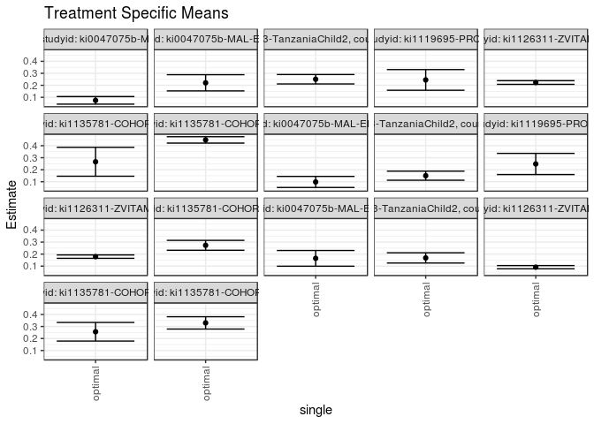

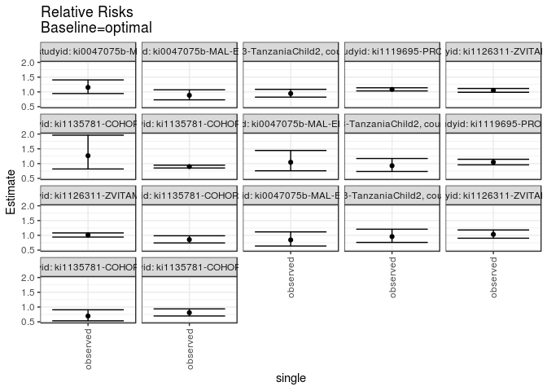

## Results Table

### Parameter: TSM

| agecat | studyid | country | intervention_level | baseline_level | estimate | ci_lower | ci_upper |
| --- | --- | --- | --- | --- | --- | --- | --- |
| 0-24 months | ki0047075b-MAL-ED | PERU | optimal | NA | 0.0747266 | 0.0431539 | 0.1062992 |
| 0-24 months | ki0047075b-MAL-ED | SOUTH AFRICA | optimal | NA | 0.2208834 | 0.1534946 | 0.2882723 |
| 0-24 months | ki1066203-TanzaniaChild2 | TANZANIA, UNITED REPUBLIC OF | optimal | NA | 0.2506600 | 0.2114026 | 0.2899173 |
| 0-24 months | ki1119695-PROBIT | BELARUS | optimal | NA | 0.2449159 | 0.1588588 | 0.3309731 |
| 0-24 months | ki1126311-ZVITAMBO | ZIMBABWE | optimal | NA | 0.2233195 | 0.2080227 | 0.2386162 |
| 0-24 months | ki1135781-COHORTS | GUATEMALA | optimal | NA | 0.2661849 | 0.1456920 | 0.3866777 |
| 0-24 months | ki1135781-COHORTS | PHILIPPINES | optimal | NA | 0.4481375 | 0.4215521 | 0.4747228 |
| 0-6 months | ki0047075b-MAL-ED | SOUTH AFRICA | optimal | NA | 0.0981103 | 0.0520142 | 0.1442064 |
| 0-6 months | ki1066203-TanzaniaChild2 | TANZANIA, UNITED REPUBLIC OF | optimal | NA | 0.1501697 | 0.1124665 | 0.1878728 |
| 0-6 months | ki1119695-PROBIT | BELARUS | optimal | NA | 0.2479628 | 0.1598038 | 0.3361218 |
| 0-6 months | ki1126311-ZVITAMBO | ZIMBABWE | optimal | NA | 0.1790230 | 0.1649777 | 0.1930682 |
| 0-6 months | ki1135781-COHORTS | PHILIPPINES | optimal | NA | 0.2731735 | 0.2318365 | 0.3145104 |
| 6-24 months | ki0047075b-MAL-ED | SOUTH AFRICA | optimal | NA | 0.1647302 | 0.0993488 | 0.2301116 |
| 6-24 months | ki1066203-TanzaniaChild2 | TANZANIA, UNITED REPUBLIC OF | optimal | NA | 0.1683585 | 0.1256042 | 0.2111128 |
| 6-24 months | ki1126311-ZVITAMBO | ZIMBABWE | optimal | NA | 0.0911754 | 0.0777615 | 0.1045893 |
| 6-24 months | ki1135781-COHORTS | GUATEMALA | optimal | NA | 0.2561808 | 0.1788550 | 0.3335066 |
| 6-24 months | ki1135781-COHORTS | PHILIPPINES | optimal | NA | 0.3299852 | 0.2786081 | 0.3813622 |

### Parameter: E(Y)

| agecat | studyid | country | intervention_level | baseline_level | estimate | ci_lower | ci_upper |
| --- | --- | --- | --- | --- | --- | --- | --- |
| 0-24 months | ki0047075b-MAL-ED | PERU | observed | NA | 0.0860927 | 0.0544044 | 0.1177810 |
| 0-24 months | ki0047075b-MAL-ED | SOUTH AFRICA | observed | NA | 0.1955128 | 0.1514355 | 0.2395901 |
| 0-24 months | ki1066203-TanzaniaChild2 | TANZANIA, UNITED REPUBLIC OF | observed | NA | 0.2370526 | 0.2199455 | 0.2541598 |
| 0-24 months | ki1119695-PROBIT | BELARUS | observed | NA | 0.2655346 | 0.1719990 | 0.3590703 |
| 0-24 months | ki1126311-ZVITAMBO | ZIMBABWE | observed | NA | 0.2344594 | 0.2274118 | 0.2415070 |
| 0-24 months | ki1135781-COHORTS | GUATEMALA | observed | NA | 0.3373494 | 0.2988711 | 0.3758277 |
| 0-24 months | ki1135781-COHORTS | PHILIPPINES | observed | NA | 0.4026622 | 0.3851243 | 0.4202002 |
| 0-6 months | ki0047075b-MAL-ED | SOUTH AFRICA | observed | NA | 0.1025641 | 0.0688457 | 0.1362825 |
| 0-6 months | ki1066203-TanzaniaChild2 | TANZANIA, UNITED REPUBLIC OF | observed | NA | 0.1393684 | 0.1254369 | 0.1532999 |
| 0-6 months | ki1119695-PROBIT | BELARUS | observed | NA | 0.2599065 | 0.1654090 | 0.3544039 |
| 0-6 months | ki1126311-ZVITAMBO | ZIMBABWE | observed | NA | 0.1806250 | 0.1742041 | 0.1870460 |
| 0-6 months | ki1135781-COHORTS | PHILIPPINES | observed | NA | 0.2336884 | 0.2185531 | 0.2488237 |
| 6-24 months | ki0047075b-MAL-ED | SOUTH AFRICA | observed | NA | 0.1389961 | 0.0967835 | 0.1812087 |
| 6-24 months | ki1066203-TanzaniaChild2 | TANZANIA, UNITED REPUBLIC OF | observed | NA | 0.1612581 | 0.1451483 | 0.1773679 |
| 6-24 months | ki1126311-ZVITAMBO | ZIMBABWE | observed | NA | 0.0940845 | 0.0885396 | 0.0996294 |
| 6-24 months | ki1135781-COHORTS | GUATEMALA | observed | NA | 0.1781076 | 0.1457776 | 0.2104376 |
| 6-24 months | ki1135781-COHORTS | PHILIPPINES | observed | NA | 0.2670270 | 0.2505637 | 0.2834903 |

### Parameter: RR

| agecat | studyid | country | intervention_level | baseline_level | estimate | ci_lower | ci_upper |
| --- | --- | --- | --- | --- | --- | --- | --- |
| 0-24 months | ki0047075b-MAL-ED | PERU | observed | optimal | 1.1521033 | 0.9442995 | 1.4056365 |
| 0-24 months | ki0047075b-MAL-ED | SOUTH AFRICA | observed | optimal | 0.8851403 | 0.7312030 | 1.0714854 |
| 0-24 months | ki1066203-TanzaniaChild2 | TANZANIA, UNITED REPUBLIC OF | observed | optimal | 0.9457139 | 0.8231733 | 1.0864964 |
| 0-24 months | ki1119695-PROBIT | BELARUS | observed | optimal | 1.0841869 | 1.0323431 | 1.1386342 |
| 0-24 months | ki1126311-ZVITAMBO | ZIMBABWE | observed | optimal | 1.0498835 | 0.9873993 | 1.1163217 |
| 0-24 months | ki1135781-COHORTS | GUATEMALA | observed | optimal | 1.2673500 | 0.8184251 | 1.9625204 |
| 0-24 months | ki1135781-COHORTS | PHILIPPINES | observed | optimal | 0.8985239 | 0.8517031 | 0.9479187 |
| 0-6 months | ki0047075b-MAL-ED | SOUTH AFRICA | observed | optimal | 1.0453959 | 0.7565880 | 1.4444486 |
| 0-6 months | ki1066203-TanzaniaChild2 | TANZANIA, UNITED REPUBLIC OF | observed | optimal | 0.9280731 | 0.7343659 | 1.1728753 |
| 0-6 months | ki1119695-PROBIT | BELARUS | observed | optimal | 1.0481672 | 0.9584705 | 1.1462579 |
| 0-6 months | ki1126311-ZVITAMBO | ZIMBABWE | observed | optimal | 1.0089490 | 0.9411419 | 1.0816415 |
| 0-6 months | ki1135781-COHORTS | PHILIPPINES | observed | optimal | 0.8554580 | 0.7426364 | 0.9854195 |
| 6-24 months | ki0047075b-MAL-ED | SOUTH AFRICA | observed | optimal | 0.8437805 | 0.6378186 | 1.1162508 |
| 6-24 months | ki1066203-TanzaniaChild2 | TANZANIA, UNITED REPUBLIC OF | observed | optimal | 0.9578255 | 0.7597663 | 1.2075157 |
| 6-24 months | ki1126311-ZVITAMBO | ZIMBABWE | observed | optimal | 1.0319069 | 0.9017997 | 1.1807852 |
| 6-24 months | ki1135781-COHORTS | GUATEMALA | observed | optimal | 0.6952419 | 0.5327025 | 0.9073757 |
| 6-24 months | ki1135781-COHORTS | PHILIPPINES | observed | optimal | 0.8092092 | 0.6979210 | 0.9382430 |

### Parameter: PAR

| agecat | studyid | country | intervention_level | baseline_level | estimate | ci_lower | ci_upper |
| --- | --- | --- | --- | --- | --- | --- | --- |
| 0-24 months | ki0047075b-MAL-ED | PERU | optimal | NA | 0.0113662 | -0.0039787 | 0.0267110 |
| 0-24 months | ki0047075b-MAL-ED | SOUTH AFRICA | optimal | NA | -0.0253706 | -0.0683341 | 0.0175929 |
| 0-24 months | ki1066203-TanzaniaChild2 | TANZANIA, UNITED REPUBLIC OF | optimal | NA | -0.0136073 | -0.0484092 | 0.0211945 |
| 0-24 months | ki1119695-PROBIT | BELARUS | optimal | NA | 0.0206187 | 0.0060579 | 0.0351795 |
| 0-24 months | ki1126311-ZVITAMBO | ZIMBABWE | optimal | NA | 0.0111399 | -0.0025649 | 0.0248448 |
| 0-24 months | ki1135781-COHORTS | GUATEMALA | optimal | NA | 0.0711645 | -0.0454673 | 0.1877963 |
| 0-24 months | ki1135781-COHORTS | PHILIPPINES | optimal | NA | -0.0454752 | -0.0690075 | -0.0219429 |
| 0-6 months | ki0047075b-MAL-ED | SOUTH AFRICA | optimal | NA | 0.0044538 | -0.0272462 | 0.0361538 |
| 0-6 months | ki1066203-TanzaniaChild2 | TANZANIA, UNITED REPUBLIC OF | optimal | NA | -0.0108012 | -0.0459324 | 0.0243299 |
| 0-6 months | ki1119695-PROBIT | BELARUS | optimal | NA | 0.0119437 | -0.0115461 | 0.0354335 |
| 0-6 months | ki1126311-ZVITAMBO | ZIMBABWE | optimal | NA | 0.0016021 | -0.0108522 | 0.0140563 |
| 0-6 months | ki1135781-COHORTS | PHILIPPINES | optimal | NA | -0.0394850 | -0.0780232 | -0.0009468 |
| 6-24 months | ki0047075b-MAL-ED | SOUTH AFRICA | optimal | NA | -0.0257341 | -0.0718961 | 0.0204280 |
| 6-24 months | ki1066203-TanzaniaChild2 | TANZANIA, UNITED REPUBLIC OF | optimal | NA | -0.0071004 | -0.0461209 | 0.0319200 |
| 6-24 months | ki1126311-ZVITAMBO | ZIMBABWE | optimal | NA | 0.0029091 | -0.0093798 | 0.0151981 |
| 6-24 months | ki1135781-COHORTS | GUATEMALA | optimal | NA | -0.0780732 | -0.1458943 | -0.0102521 |
| 6-24 months | ki1135781-COHORTS | PHILIPPINES | optimal | NA | -0.0629581 | -0.1116255 | -0.0142908 |

### Parameter: PAF

| agecat | studyid | country | intervention_level | baseline_level | estimate | ci_lower | ci_upper |
| --- | --- | --- | --- | --- | --- | --- | --- |
| 0-24 months | ki0047075b-MAL-ED | PERU | optimal | NA | 0.1320222 | -0.0589860 | 0.2885785 |
| 0-24 months | ki0047075b-MAL-ED | SOUTH AFRICA | optimal | NA | -0.1297644 | -0.3676093 | 0.0667162 |
| 0-24 months | ki1066203-TanzaniaChild2 | TANZANIA, UNITED REPUBLIC OF | optimal | NA | -0.0574022 | -0.2148111 | 0.0796104 |
| 0-24 months | ki1119695-PROBIT | BELARUS | optimal | NA | 0.0776498 | 0.0313298 | 0.1217548 |
| 0-24 months | ki1126311-ZVITAMBO | ZIMBABWE | optimal | NA | 0.0475133 | -0.0127615 | 0.1042008 |
| 0-24 months | ki1135781-COHORTS | GUATEMALA | optimal | NA | 0.2109520 | -0.2218589 | 0.4904512 |
| 0-24 months | ki1135781-COHORTS | PHILIPPINES | optimal | NA | -0.1129364 | -0.1741181 | -0.0549428 |
| 0-6 months | ki0047075b-MAL-ED | SOUTH AFRICA | optimal | NA | 0.0434246 | -0.3217233 | 0.3076943 |
| 0-6 months | ki1066203-TanzaniaChild2 | TANZANIA, UNITED REPUBLIC OF | optimal | NA | -0.0775014 | -0.3617190 | 0.1473944 |
| 0-6 months | ki1119695-PROBIT | BELARUS | optimal | NA | 0.0459537 | -0.0433289 | 0.1275959 |
| 0-6 months | ki1126311-ZVITAMBO | ZIMBABWE | optimal | NA | 0.0088696 | -0.0625390 | 0.0754793 |
| 0-6 months | ki1135781-COHORTS | PHILIPPINES | optimal | NA | -0.1689645 | -0.3465540 | -0.0147963 |
| 6-24 months | ki0047075b-MAL-ED | SOUTH AFRICA | optimal | NA | -0.1851423 | -0.5678438 | 0.1041440 |
| 6-24 months | ki1066203-TanzaniaChild2 | TANZANIA, UNITED REPUBLIC OF | optimal | NA | -0.0440315 | -0.3161942 | 0.1718534 |
| 6-24 months | ki1126311-ZVITAMBO | ZIMBABWE | optimal | NA | 0.0309203 | -0.1088936 | 0.1531059 |
| 6-24 months | ki1135781-COHORTS | GUATEMALA | optimal | NA | -0.4383484 | -0.8772206 | -0.1020794 |
| 6-24 months | ki1135781-COHORTS | PHILIPPINES | optimal | NA | -0.2357744 | -0.4328270 | -0.0658219 |